RtidymodelsglmnetRegularization

# Ridge, Lasso & Elastic Net Regression

A comparative analysis of regularized regression methods for predicting geographic origin of music from audio features, with hyperparameter tuning via 10-fold cross-validation.

Author **Saroj Bhatta**

Dataset **music.csv (500 obs, 73 vars)**

Methods **Ridge · Lasso · Elastic Net**

## Overview

This analysis explores regularized regression methods—ridge regression, lasso, and elastic net—as alternatives to ordinary least squares when predictors are numerous or correlated. The task is to predict the geographic **latitude** of a music track's origin from 72 audio feature variables. With a high-dimensional predictor space relative to sample size, standard OLS may overfit; regularization addresses this by penalizing coefficient magnitude.

500

Total observations

73

Variables (72 predictors)

375 / 125

Train / Test split

## Data & Outcome Distribution

The music dataset was split into a training set (375 observations) and test set (125 observations) using a 75/25 proportional split with seed 7 for reproducibility. The outcome variable `lat` represents the latitude of a music track's geographic origin.

```
set.seed(7)
music <- read_csv("data/music.csv", show_col_types = FALSE)
music_split <- initial_split(music, prop = 3/4)
music_train <- training(music_split)
music_test  <- testing(music_split)
```

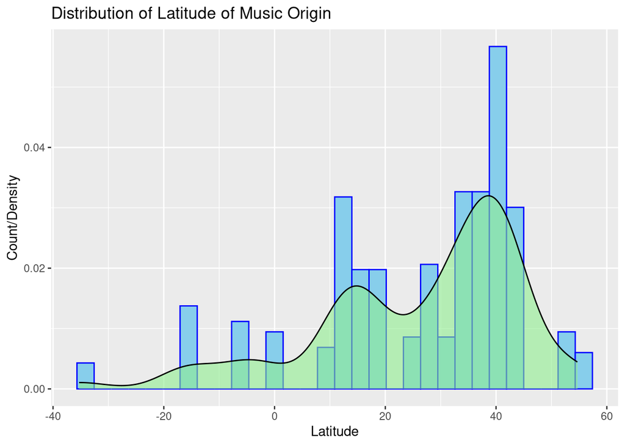

Figure 1. Distribution of latitude (outcome variable) in the training set, showing the geographic spread of music origins.

## Baseline: Ordinary Least Squares

As a baseline, an OLS model using all 72 predictors was fit on the training data and evaluated on the test set.

```
lm_spec <- linear_reg() |> set_engine("lm")
lm_fit  <- fit(lm_spec, lat ~ ., data = music_train)

preds <- lm_fit |>
  predict(new_data = music_test) |>
  bind_cols(music_test)

rmse(preds, truth = lat, estimate = .pred)
```

# A tibble: 1 × 3 .metric .estimator .estimate <chr> <chr> <dbl> 1 rmse standard 17.0

The baseline OLS test RMSE is **17.03**. This serves as the benchmark against which regularized models are compared.

## Ridge Regression with Cross-Validated λ

Ridge regression adds an L2 penalty to the OLS objective, shrinking all coefficients toward zero without setting any to exactly zero. The penalty parameter λ (lambda) controls the degree of shrinkage. A 10-fold cross-validation grid search was conducted over λ values from 0 to 100.

```
music_cv  <- vfold_cv(data = music_train, v = 10)

reg_recipe <- recipe(lat ~ ., data = music_train) |>
  step_dummy(all_nominal()) |>
  step_scale(all_predictors())

ridge_spec <- linear_reg(penalty = tune(), mixture = 0) |>
  set_engine("glmnet")

ridge_grid   <- expand_grid(penalty = seq(0, 100, by = 10))
ridge_results <- tune_grid(ridge_spec,
                           preprocessor = reg_recipe,
                           grid = ridge_grid,
                           resamples = music_cv)
```

# Best lambda selected by lowest CV RMSE: # A tibble: 1 × 2 penalty .config <dbl> <chr> 1 10 Preprocessor1_Model02 CV RMSE at λ=10: 17.06 Test RMSE at λ=10: 16.54

The cross-validation selected **λ = 10** as the optimal penalty, yielding a CV RMSE of 17.06. Applied to the held-out test set, this model achieves a test RMSE of **16.54**—an improvement over the OLS baseline of 17.03. This improvement demonstrates that mild regularization reduces overfitting even with only 375 training observations.

### Variable Inclusion in Ridge

Ridge regression retains all 72 predictors in the model, but shrinks their coefficients toward zero proportional to their contribution to prediction error. Unlike lasso, ridge does not perform variable selection—it produces a dense solution where all coefficients are non-zero, though many may be very small.

```
final_fit |>
  tidy() |>
  filter(term != "(Intercept)") |>
  arrange(desc(abs(estimate)))
```

[figure not shown]

## Lasso Regression

Lasso (Least Absolute Shrinkage and Selection Operator) applies an L1 penalty, which has the property of setting some coefficients to exactly zero—performing automatic variable selection. This can be advantageous when only a subset of predictors are truly informative.

## Elastic Net

Elastic net combines L1 and L2 penalties, interpolating between ridge and lasso via the `mixture` parameter (α). When α = 0, elastic net reduces to ridge; when α = 1, it reduces to lasso. Tuning both `penalty` and `mixture` allows the model to adaptively select the appropriate regularization structure.

## Model Comparison

[output not shown]

### Summary

The key distinction between methods lies in variable selection behavior: ridge retains all predictors with shrunk coefficients, while lasso produces sparse solutions by zeroing out less informative features. Elastic net provides flexibility to balance both behaviors. The choice among methods ultimately depends on whether interpretability (lasso's sparsity) or predictive stability (ridge's smooth shrinkage) is prioritized.